# **Problem Statement**

## Business Context

A sales forecast is a prediction of future sales revenue based on historical data, industry trends, and the status of the current sales pipeline. Businesses use the sales forecast to estimate weekly, monthly, quarterly, and annual sales totals. A company needs to make an accurate sales forecast as it adds value across an organization and helps the different verticals to chalk out their future course of action.

Forecasting helps an organization plan its sales operations by region and provides valuable insights to the supply chain team regarding the procurement of goods and materials. An accurate sales forecast process has many benefits which include improved decision-making about the future and reduction of sales pipeline and forecast risks. Moreover, it helps to reduce the time spent in planning territory coverage and establish benchmarks that can be used to assess trends in the future.

## Objective

SuperKart is a retail chain operating supermarkets and food marts across various tier cities, offering a wide range of products. To optimize its inventory management and make informed decisions around regional sales strategies, SuperKart wants to accurately forecast the sales revenue of its outlets for the upcoming quarter.

To operationalize these insights at scale, the company has partnered with a data science firm—not just to build a predictive model based on historical sales data, but to develop and deploy a robust forecasting solution that can be integrated into SuperKart’s decision-making systems and used across its network of stores.

## Data Description

The data contains the different attributes of the various products and stores.The detailed data dictionary is given below.

- **Product_Id** - unique identifier of each product, each identifier having two letters at the beginning followed by a number.
- **Product_Weight** - weight of each product
- **Product_Sugar_Content** - sugar content of each product like low sugar, regular and no sugar
- **Product_Allocated_Area** - ratio of the allocated display area of each product to the total display area of all the products in a store
- **Product_Type** - broad category for each product like meat, snack foods, hard drinks, dairy, canned, soft drinks, health and hygiene, baking goods, bread, breakfast, frozen foods, fruits and vegetables, household, seafood, starchy foods, others
- **Product_MRP** - maximum retail price of each product
- **Store_Id** - unique identifier of each store
- **Store_Establishment_Year** - year in which the store was established
- **Store_Size** - size of the store depending on sq. feet like high, medium and low
- **Store_Location_City_Type** - type of city in which the store is located like Tier 1, Tier 2 and Tier 3. Tier 1 consists of cities where the standard of living is comparatively higher than its Tier 2 and Tier 3 counterparts.
- **Store_Type** - type of store depending on the products that are being sold there like Departmental Store, Supermarket Type 1, Supermarket Type 2 and Food Mart
- **Product_Store_Sales_Total** - total revenue generated by the sale of that particular product in that particular store

# **Installing and Importing the necessary libraries**

```python
#Installing the libraries with the specified versions
!pip install numpy==2.0.2 pandas==2.2.2 scikit-learn==1.6.1 matplotlib==3.10.0 seaborn==0.13.2 joblib==1.4.2 xgboost==2.1.4 requests==2.32.3 huggingface_hub==0.30.1 -q
```

```
   ━━━━━━━━━━━━━━━━━━━━━━━━━━━━━━━━━━━━━━━━ 301.8/301.8 kB 9.0 MB/s eta 0:00:00
   ━━━━━━━━━━━━━━━━━━━━━━━━━━━━━━━━━━━━━━━━ 481.2/481.2 kB 17.7 MB/s eta 0:00:00
```

**Note:**

- After running the above cell, kindly restart the notebook kernel (for Jupyter Notebook) or runtime (for Google Colab) and run all cells sequentially from the next cell.
- On executing the above line of code, you might see a warning regarding package dependencies. This error message can be ignored as the above code ensures that all necessary libraries and their dependencies are maintained to successfully execute the code in this notebook.

```python
import warnings
warnings.filterwarnings("ignore")

# Libraries to help with reading and manipulating data
import numpy as np
import pandas as pd

# For splitting the dataset
from sklearn.model_selection import train_test_split

# Libaries to help with data visualization
import matplotlib.pyplot as plt
import seaborn as sns

# Removes the limit for the number of displayed columns
pd.set_option("display.max_columns", None)
# Sets the limit for the number of displayed rows
pd.set_option("display.max_rows", 100)


# Libraries different ensemble classifiers
from sklearn.ensemble import (
    BaggingRegressor,
    RandomForestRegressor,
    AdaBoostRegressor,
    GradientBoostingRegressor,
)
from xgboost import XGBRegressor
from sklearn.tree import DecisionTreeRegressor

# Libraries to get different metric scores
from sklearn.metrics import (
    confusion_matrix,
    accuracy_score,
    precision_score,
    recall_score,
    f1_score,
    mean_squared_error,
    mean_absolute_error,
    r2_score,
    mean_absolute_percentage_error
)

# To create the pipeline
from sklearn.compose import make_column_transformer, ColumnTransformer
from sklearn.pipeline import make_pipeline,Pipeline

# To tune different models and standardize
from sklearn.model_selection import GridSearchCV
from sklearn.preprocessing import StandardScaler,OneHotEncoder, FunctionTransformer

from datetime import datetime

# To serialize the model
import joblib

# os related functionalities
import os

# API request
import requests

# for hugging face space authentication to upload files
from huggingface_hub import login, HfApi
```

```python
print(np.__version__)
print(pd.__version__)
```

```
2.0.2
2.2.2
```

# **Loading the dataset**

```python
from google.colab import drive
drive.mount('/content/drive')
```

```python
sk_ds = pd.read_csv('/content/drive/MyDrive/Colab Notebooks/PGAIML/MachineLearning/SuperKart-Model Deployment Project/SuperKart.csv')
```

```python
print(sk_ds.shape)
sk_ds.head()
```

```
(8763, 12)
```

|  | Product_Id | Product_Weight | Product_Sugar_Content | Product_Allocated_Area | Product_Type | Product_MRP | Store_Id | Store_Establishment_Year | Store_Size | Store_Location_City_Type | Store_Type | Product_Store_Sales_Total |
| --- | --- | --- | --- | --- | --- | --- | --- | --- | --- | --- | --- | --- |
| 0 | FD6114 | 12.66 | Low Sugar | 0.027 | Frozen Foods | 117.08 | OUT004 | 2009 | Medium | Tier 2 | Supermarket Type2 | 2842.40 |
| 1 | FD7839 | 16.54 | Low Sugar | 0.144 | Dairy | 171.43 | OUT003 | 1999 | Medium | Tier 1 | Departmental Store | 4830.02 |
| 2 | FD5075 | 14.28 | Regular | 0.031 | Canned | 162.08 | OUT001 | 1987 | High | Tier 2 | Supermarket Type1 | 4130.16 |
| 3 | FD8233 | 12.10 | Low Sugar | 0.112 | Baking Goods | 186.31 | OUT001 | 1987 | High | Tier 2 | Supermarket Type1 | 4132.18 |
| 4 | NC1180 | 9.57 | No Sugar | 0.010 | Health and Hygiene | 123.67 | OUT002 | 1998 | Small | Tier 3 | Food Mart | 2279.36 |

```python
skdf = sk_ds.copy()
```

- Created a copy of Super Kard original dataset to SuperKart dataframe for further processing.

# **Data Overview**

```python
print(skdf.shape)
skdf.head()
```

```
(8763, 12)
```

|  | Product_Id | Product_Weight | Product_Sugar_Content | Product_Allocated_Area | Product_Type | Product_MRP | Store_Id | Store_Establishment_Year | Store_Size | Store_Location_City_Type | Store_Type | Product_Store_Sales_Total |
| --- | --- | --- | --- | --- | --- | --- | --- | --- | --- | --- | --- | --- |
| 0 | FD6114 | 12.66 | Low Sugar | 0.027 | Frozen Foods | 117.08 | OUT004 | 2009 | Medium | Tier 2 | Supermarket Type2 | 2842.40 |
| 1 | FD7839 | 16.54 | Low Sugar | 0.144 | Dairy | 171.43 | OUT003 | 1999 | Medium | Tier 1 | Departmental Store | 4830.02 |
| 2 | FD5075 | 14.28 | Regular | 0.031 | Canned | 162.08 | OUT001 | 1987 | High | Tier 2 | Supermarket Type1 | 4130.16 |
| 3 | FD8233 | 12.10 | Low Sugar | 0.112 | Baking Goods | 186.31 | OUT001 | 1987 | High | Tier 2 | Supermarket Type1 | 4132.18 |
| 4 | NC1180 | 9.57 | No Sugar | 0.010 | Health and Hygiene | 123.67 | OUT002 | 1998 | Small | Tier 3 | Food Mart | 2279.36 |

```python
skdf.info()
```

```
<class 'pandas.core.frame.DataFrame'>
RangeIndex: 8763 entries, 0 to 8762
Data columns (total 12 columns):
 #   Column                     Non-Null Count  Dtype
---  ------                     --------------  -----
 0   Product_Id                 8763 non-null   object
 1   Product_Weight             8763 non-null   float64
 2   Product_Sugar_Content      8763 non-null   object
 3   Product_Allocated_Area     8763 non-null   float64
 4   Product_Type               8763 non-null   object
 5   Product_MRP                8763 non-null   float64
 6   Store_Id                   8763 non-null   object
 7   Store_Establishment_Year   8763 non-null   int64
 8   Store_Size                 8763 non-null   object
 9   Store_Location_City_Type   8763 non-null   object
 10  Store_Type                 8763 non-null   object
 11  Product_Store_Sales_Total  8763 non-null   float64
dtypes: float64(4), int64(1), object(7)
memory usage: 821.7+ KB
```

# **Exploratory Data Analysis (EDA)**

```python
skdf.describe(include=object)
```

|  | Product_Id | Product_Sugar_Content | Product_Type | Store_Id | Store_Size | Store_Location_City_Type | Store_Type |
| --- | --- | --- | --- | --- | --- | --- | --- |
| count | 8763 | 8763 | 8763 | 8763 | 8763 | 8763 | 8763 |
| unique | 8763 | 4 | 16 | 4 | 3 | 3 | 4 |
| top | FD306 | Low Sugar | Fruits and Vegetables | OUT004 | Medium | Tier 2 | Supermarket Type2 |
| freq | 1 | 4885 | 1249 | 4676 | 6025 | 6262 | 4676 |

```python
skdf.describe()
```

|  | Product_Weight | Product_Allocated_Area | Product_MRP | Store_Establishment_Year | Product_Store_Sales_Total |
| --- | --- | --- | --- | --- | --- |
| count | 8763.000000 | 8763.000000 | 8763.000000 | 8763.000000 | 8763.000000 |
| mean | 12.653792 | 0.068786 | 147.032539 | 2002.032751 | 3464.003640 |
| std | 2.217320 | 0.048204 | 30.694110 | 8.388381 | 1065.630494 |
| min | 4.000000 | 0.004000 | 31.000000 | 1987.000000 | 33.000000 |
| 25% | 11.150000 | 0.031000 | 126.160000 | 1998.000000 | 2761.715000 |
| 50% | 12.660000 | 0.056000 | 146.740000 | 2009.000000 | 3452.340000 |
| 75% | 14.180000 | 0.096000 | 167.585000 | 2009.000000 | 4145.165000 |
| max | 22.000000 | 0.298000 | 266.000000 | 2009.000000 | 8000.000000 |

```python
skdf.isnull().sum()
```

|  | 0 |
| --- | --- |
| Product_Id | 0 |
| Product_Weight | 0 |
| Product_Sugar_Content | 0 |
| Product_Allocated_Area | 0 |
| Product_Type | 0 |
| Product_MRP | 0 |
| Store_Id | 0 |
| Store_Establishment_Year | 0 |
| Store_Size | 0 |
| Store_Location_City_Type | 0 |
| Store_Type | 0 |
| Product_Store_Sales_Total | 0 |

**dtype:** int64

```python
skdf.isna().sum()
```

|  | 0 |
| --- | --- |
| Product_Id | 0 |
| Product_Weight | 0 |
| Product_Sugar_Content | 0 |
| Product_Allocated_Area | 0 |
| Product_Type | 0 |
| Product_MRP | 0 |
| Store_Id | 0 |
| Store_Establishment_Year | 0 |
| Store_Size | 0 |
| Store_Location_City_Type | 0 |
| Store_Type | 0 |
| Product_Store_Sales_Total | 0 |

**dtype:** int64

```python
skdf.duplicated().sum()
```

```
np.int64(0)
```

```python
4885/8763
```

```
0.5574574917265777
```

## Univariate Analysis

```python
for column in skdf.columns:
  if skdf[column].dtype == 'object':
    print("*"*70)
    print(pd.DataFrame(skdf[column].value_counts()).join(skdf[column].value_counts(normalize=True).mul(100)))
```

```
            count  proportion
Product_Id
FD306           1    0.011412
FD6114          1    0.011412
FD7839          1    0.011412
FD5075          1    0.011412
FD8233          1    0.011412
...           ...         ...
FD1387          1    0.011412
FD1231          1    0.011412
FD5276          1    0.011412
FD8553          1    0.011412
FD6027          1    0.011412

[8763 rows x 2 columns]
                       count  proportion
Product_Sugar_Content
Low Sugar               4885   55.745749
Regular                 2251   25.687550
No Sugar                1519   17.334246
reg                      108    1.232455
                       count  proportion
Product_Type
Fruits and Vegetables   1249   14.253110
Snack Foods             1149   13.111948
Frozen Foods             811    9.254821
Dairy                    796    9.083647
Household                740    8.444597
Baking Goods             716    8.170718
Canned                   677    7.725665
Health and Hygiene       628    7.166495
Meat                     618    7.052379
Soft Drinks              519    5.922629
Breads                   200    2.282323
Hard Drinks              186    2.122561
Others                   151    1.723154
Starchy Foods            141    1.609038
Breakfast                106    1.209631
Seafood                   76    0.867283
          count  proportion
Store_Id
OUT004     4676   53.360721
OUT001     1586   18.098825
OUT003     1349   15.394271
OUT002     1152   13.146183
            count  proportion
Store_Size
Medium       6025   68.754993
High         1586   18.098825
Small        1152   13.146183
                          count  proportion
Store_Location_City_Type
Tier 2                     6262   71.459546
Tier 1                     1349   15.394271
Tier 3                     1152   13.146183
                    count  proportion
Store_Type
Supermarket Type2    4676   53.360721
Supermarket Type1    1586   18.098825
Departmental Store   1349   15.394271
Food Mart            1152   13.146183
```

```python
skdf.Product_Id.str[:2].value_counts()
```

| Product_Id | count |
| --- | --- |
| FD | 6539 |
| NC | 1519 |
| DR | 705 |

**dtype:** int64

```python
skdf.groupby(['Store_Id'])['Store_Size'].value_counts()
```

| Store_Id | Store_Size | count |
| --- | --- | --- |
| OUT001 | High | 1586 |
| OUT002 | Small | 1152 |
| OUT003 | Medium | 1349 |
| OUT004 | Medium | 4676 |

**dtype:** int64

- OUT004 is showing as Medium Store, however it has large number of products.
- Other three stores have almost 15% each of remaining products.

```python
skdf.groupby(['Store_Id','Store_Establishment_Year']).Product_Id.count()
```

| Store_Id | Store_Establishment_Year | Product_Id |
| --- | --- | --- |
| OUT001 | 1987 | 1586 |
| OUT002 | 1998 | 1152 |
| OUT003 | 1999 | 1349 |
| OUT004 | 2009 | 4676 |

**dtype:** int64

```python
# function to create labeled barplots
def labeled_barplot(data, feature, perc=False, n=None):
    """
    Barplot with percentage at the top

    data: dataframe
    feature: dataframe column
    perc: whether to display percentages instead of count (default is False)
    n: displays the top n category levels (default is None, i.e., display all levels)
    """

    total = len(data[feature])  # length of the column
    count = data[feature].nunique()
    if n is None:
        plt.figure(figsize=(count + 1, 5))
    else:
        plt.figure(figsize=(n + 1, 5))

    plt.xticks(rotation=90, fontsize=9)
    ax = sns.countplot(
        data=data,
        x=feature,
        palette="Paired",
        order=data[feature].value_counts().sort_values(ascending=False).index[:n],
    )

    for p in ax.patches:
        if perc == True:
            label = "{:.1f}%".format(
                100 * p.get_height() / total
            )  # percentage of each class of the category
        else:
            label = p.get_height()  # count of each level of the category

        x = p.get_x() + p.get_width() / 2  # width of the plot
        y = p.get_height()  # height of the plot

        ax.annotate(
            label,
            (x, y),
            ha="center",
            va="center",
            size=12,
            xytext=(0, 5),
            textcoords="offset points",
        )  # annotate the percentage

    plt.show()  # show the plot


def histogram_boxplot(data, feature, figsize=(15, 10), kde=False, bins=None):
    """
    Boxplot and histogram combined

    data: dataframe
    feature: dataframe column
    figsize: size of figure (default (15,10))
    kde: whether to show the density curve (default False)
    bins: number of bins for histogram (default None)
    """
    f2, (ax_box2, ax_hist2) = plt.subplots(
        nrows=2,  # Number of rows of the subplot grid= 2
        sharex=True,  # x-axis will be shared among all subplots
        gridspec_kw={"height_ratios": (0.25, 0.75)},
        figsize=figsize,
    )  # creating the 2 subplots
    sns.boxplot(
        data=data, x=feature, ax=ax_box2, showmeans=True, color="violet"
    )  # boxplot will be created and a triangle will indicate the mean value of the column
    sns.histplot(
        data=data, x=feature, kde=kde, ax=ax_hist2, bins=bins
    ) if bins else sns.histplot(
        data=data, x=feature, kde=kde, ax=ax_hist2
    )  # For histogram
    ax_hist2.axvline(
        data[feature].mean(), color="green", linestyle="--"
    )  # Add mean to the histogram
    ax_hist2.axvline(
        data[feature].median(), color="black", linestyle="-"
    )  # Add median to the histogram
```

```python
[x for x in skdf.columns if skdf[x].dtype != 'object']
```

```
['Product_Weight',
 'Product_Allocated_Area',
 'Product_MRP',
 'Store_Establishment_Year',
 'Product_Store_Sales_Total']
```

```python
[x for x in skdf.columns if skdf[x].dtype == 'object']
```

```
['Product_Id',
 'Product_Sugar_Content',
 'Product_Type',
 'Store_Id',
 'Store_Size',
 'Store_Location_City_Type',
 'Store_Type']
```

```
Product_Sugar_Content
```

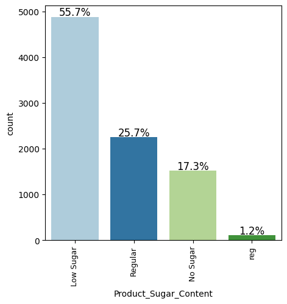

```
Product_Type
```

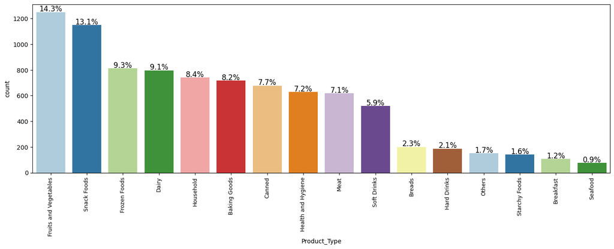

```
Store_Id
```

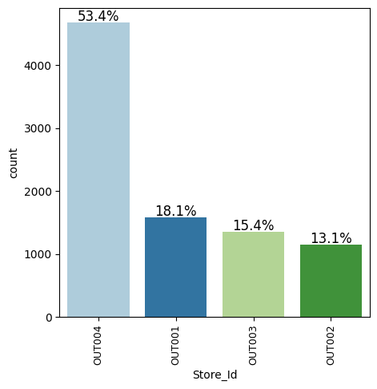

```
Store_Size
```

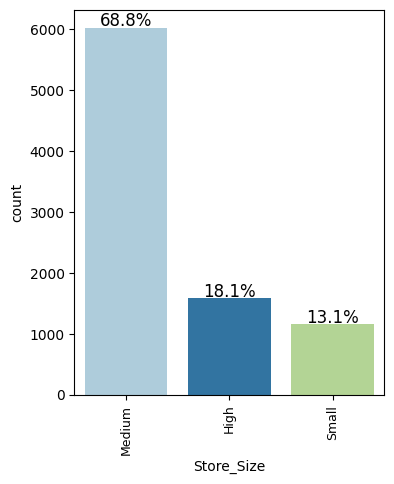

```
Store_Location_City_Type
```

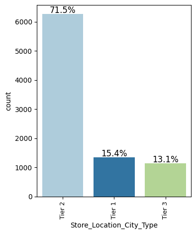

```
Store_Type
```

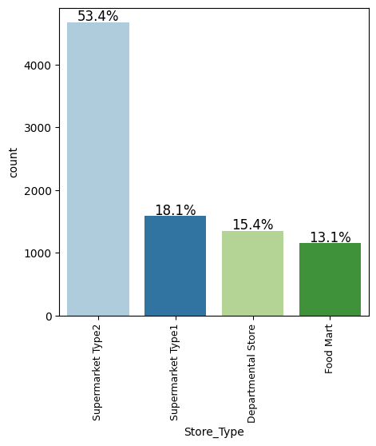

```
Store_Establishment_Year
```

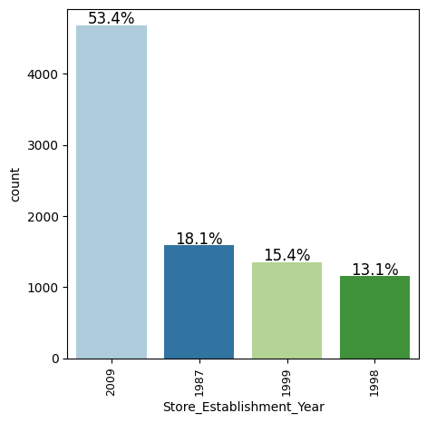

```python
for column in ['Product_Sugar_Content',  'Product_Type', 'Store_Id', 'Store_Size',  'Store_Location_City_Type',  'Store_Type', 'Store_Establishment_Year']:
  print(column)
  labeled_barplot(skdf,column,True,None)
```

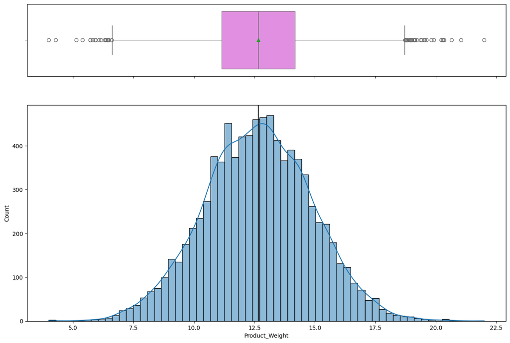

```python
# ['Product_Weight', 'Product_Allocated_Area', 'Product_MRP', 'Store_Establishment_Year', 'Product_Store_Sales_Total']
histogram_boxplot(skdf, 'Product_Weight',kde=True)
```

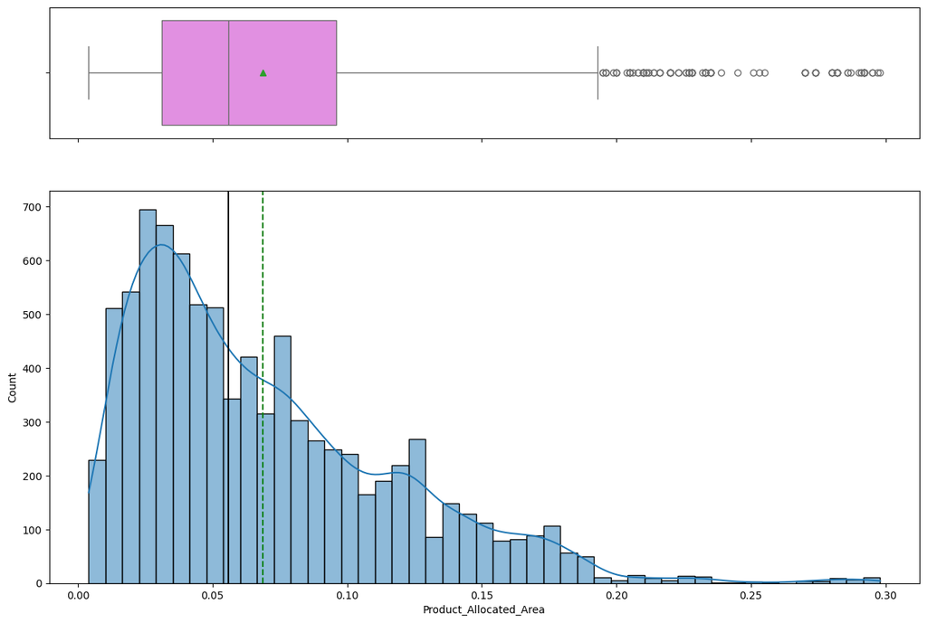

```python
histogram_boxplot(skdf, 'Product_Allocated_Area',kde=True)
```

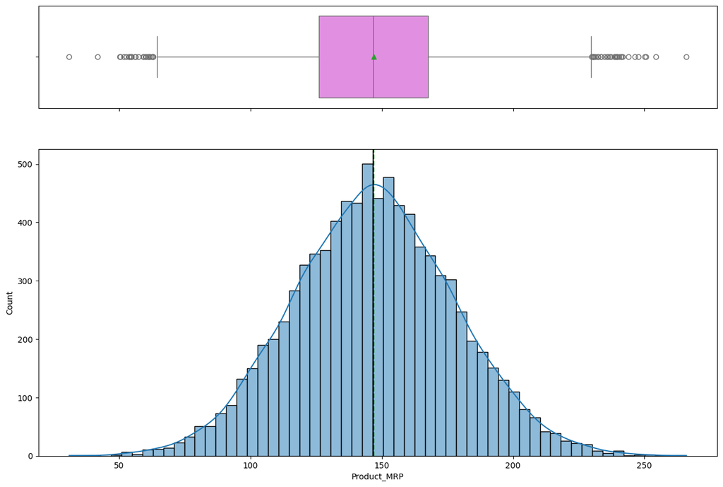

```python
histogram_boxplot(skdf, 'Product_MRP',kde=True)
```

```python
pmrp_q1 = skdf['Product_MRP'].quantile(0.25)
pmrp_q2 = skdf['Product_MRP'].quantile(0.50)
pmrp_q3 = skdf['Product_MRP'].quantile(0.75)
pmrp_iqr = pmrp_q3 - pmrp_q1
pmrp_lower_bound = pmrp_q1 - (1.5 * pmrp_iqr)
pmrp_upper_bound = pmrp_q3 + (1.5 * pmrp_iqr)

print(f"Q1: {pmrp_q1}")
print(f"Q2: {pmrp_q2}")
print(f"Q3: {pmrp_q3}")
print(f"IQR: {pmrp_iqr}")
print(f"Lower Bound: {pmrp_lower_bound}")
print(f"Upper Bound: {pmrp_upper_bound}")
```

```
Q1: 126.16
Q2: 146.74
Q3: 167.585
IQR: 41.42500000000001
Lower Bound: 64.02249999999998
Upper Bound: 229.72250000000003
```

```python
print(f"No of products outside the upper bound: {skdf[skdf['Product_MRP'] > pmrp_upper_bound].Product_Id.count()}")
print(f"No of products outside the lower bound: {skdf[skdf['Product_MRP'] < pmrp_lower_bound].Product_Id.count()}")
```

```
No of products outside the upper bound: 31
No of products outside the lower bound: 26
```

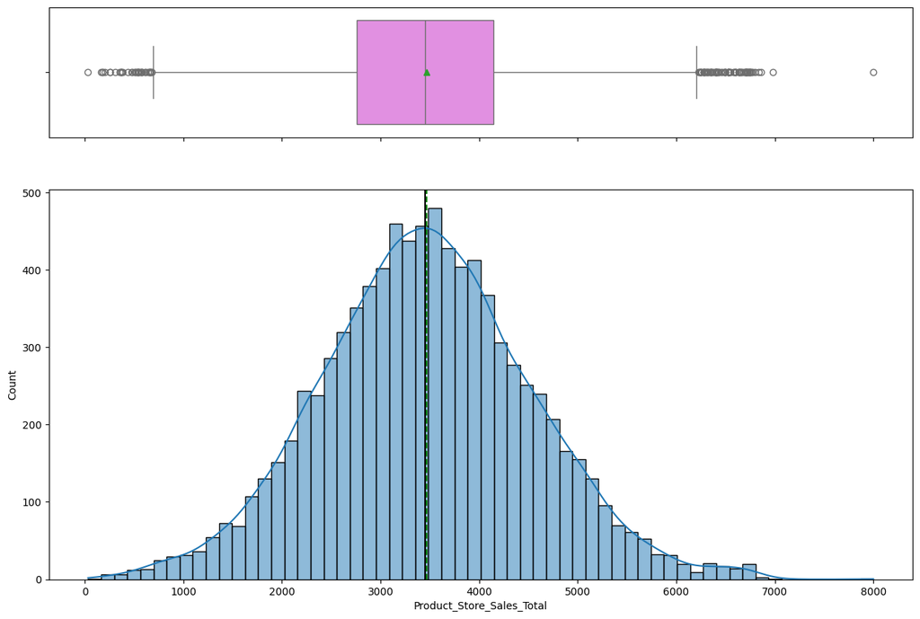

```python
histogram_boxplot(skdf, 'Product_Store_Sales_Total',kde=True)
```

```python
pst_Q1 = skdf['Product_Store_Sales_Total'].quantile(0.25)
pst_Q2 = skdf['Product_Store_Sales_Total'].quantile(0.50)
pst_Q3 = skdf['Product_Store_Sales_Total'].quantile(0.75)
pst_IQR = pst_Q3 - pst_Q1
pst_lower_bound = pst_Q1 - (1.5 * pst_IQR)
pst_upper_bound = pst_Q3 + (1.5 * pst_IQR)

print(f"Q1: {pst_Q1}")
print(f"Q2: {pst_Q2}")
print(f"Q3: {pst_Q3}")
print(f"IQR: {pst_IQR}")
print(f"Lower Bound: {pst_lower_bound}")
print(f"Upper Bound: {pst_upper_bound}")
```

```
Q1: 2761.715
Q2: 3452.34
Q3: 4145.165
IQR: 1383.4499999999998
Lower Bound: 686.5400000000004
Upper Bound: 6220.34
```

```python
print(f"No of products outside the sales upper bound: {skdf[skdf['Product_Store_Sales_Total'] > pst_upper_bound].Product_Id.count()}")
print(f"No of products outside the sales lower bound: {skdf[skdf['Product_Store_Sales_Total'] < pst_lower_bound].Product_Id.count()}")
```

```
No of products outside the sales upper bound: 82
No of products outside the sales lower bound: 37
```

**Observations:**

## Bivariate Analysis

```python
skdf.columns
```

```
Index(['Product_Id', 'Product_Weight', 'Product_Sugar_Content',
       'Product_Allocated_Area', 'Product_Type', 'Product_MRP', 'Store_Id',
       'Store_Establishment_Year', 'Store_Size', 'Store_Location_City_Type',
       'Store_Type', 'Product_Store_Sales_Total'],
      dtype='object')
```

```python
# Adding Store Establishment Year, though it is not contineous numerical value, however we can not derive age of store due to missing information like data as of.
num_features = ['Product_Weight', 'Product_Allocated_Area', 'Product_MRP', 'Product_Store_Sales_Total','Store_Establishment_Year']
cat_features = ['Product_Sugar_Content', 'Product_Type', 'Store_Id', 'Store_Size', 'Store_Location_City_Type', 'Store_Type','Store_Establishment_Year']
```

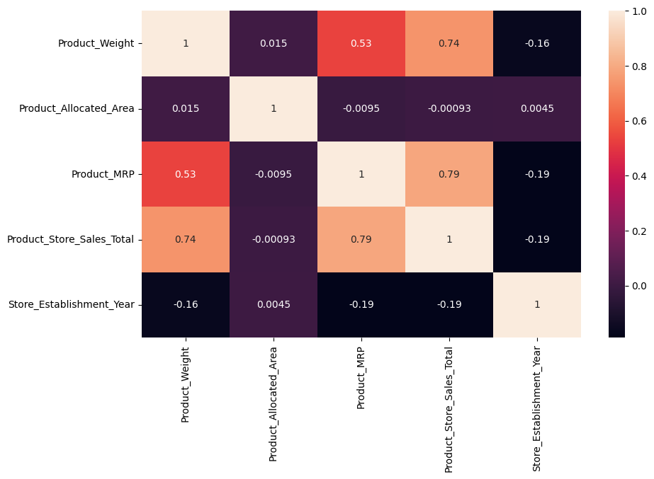

```python
plt.figure(figsize = (10,6))
sns.heatmap(skdf[num_features].corr(), annot=True)
plt.show()
```

- **Product MRP and Product weight has a stronger positive correlation with target variable "Sales Total".**
- Product Allocated Area has weeaker correlation with target variable.
- Store established year has weak negative correlation with target variable.
- Product MRP has moderate positive correlation with Product weight.
- **This suggests Product MRP and Product Weight will likely be important features for sales forecast.**

'Product_Id', 'Product_Weight', 'Product_Sugar_Content', 'Product_Allocated_Area', 'Product_Type', 'Product_MRP', 'Store_Id', 'Store_Establishment_Year', 'Store_Size', 'Store_Location_City_Type', 'Store_Type', 'Product_Store_Sales_Total'

```python
skdf.groupby(['Product_Sugar_Content'])['Product_Store_Sales_Total'].agg([sum, min, max, np.mean, np.median, np.std])
```

| Product_Sugar_Content | sum | min | max | mean | median | std |
| --- | --- | --- | --- | --- | --- | --- |
| Low Sugar | 16823405.80 | 33.00 | 6977.43 | 3443.890645 | 3428.32 | 1062.540506 |
| No Sugar | 5269943.68 | 253.53 | 8000.00 | 3469.350678 | 3469.66 | 1063.841934 |
| Regular | 7867671.29 | 203.55 | 6862.43 | 3495.189378 | 3495.09 | 1074.592653 |
| reg | 394043.13 | 1223.90 | 5917.10 | 3648.547500 | 3650.66 | 1022.034087 |

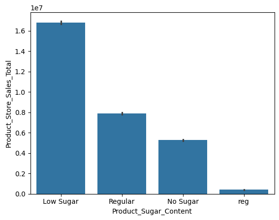

```python
sns.barplot(x='Product_Sugar_Content', y='Product_Store_Sales_Total', data=skdf, estimator=sum)
plt.show()
```

- Above graph shows imbalance of sales accross product sugar content categories.
- However, mean, median and std are close to each other category.
- This suggest the sugar content of a product might not be a strong driving factor of total sales.
- **Clean the data by updating reg to Regular; and perform One Hot Encoding**

```python
skdf.groupby(['Product_Type'])['Product_Store_Sales_Total'].agg([ sum, min, max, np.mean, np.median, np.std])
```

| Product_Type | sum | min | max | mean | median | std |
| --- | --- | --- | --- | --- | --- | --- |
| Baking Goods | 2452986.00 | 203.55 | 6763.94 | 3425.958101 | 3377.725 | 1049.975099 |
| Breads | 714942.24 | 830.76 | 6660.96 | 3574.711200 | 3486.950 | 1071.626114 |
| Breakfast | 362130.41 | 657.14 | 6796.94 | 3416.324623 | 3468.500 | 1142.438697 |
| Canned | 2300082.71 | 180.86 | 6862.43 | 3397.463383 | 3381.600 | 1059.943714 |
| Dairy | 2811918.04 | 183.02 | 6835.81 | 3532.560352 | 3536.275 | 1101.907437 |
| Frozen Foods | 2809980.83 | 350.00 | 6747.70 | 3464.834562 | 3458.090 | 1037.522826 |
| Fruits and Vegetables | 4300833.27 | 366.37 | 6744.58 | 3443.421353 | 3440.900 | 1045.297733 |
| Hard Drinks | 625814.62 | 705.86 | 6347.57 | 3364.594731 | 3337.970 | 1061.714881 |
| Health and Hygiene | 2163707.21 | 253.53 | 6643.63 | 3445.393646 | 3449.280 | 1069.719743 |
| Household | 2564740.17 | 512.42 | 8000.00 | 3465.865095 | 3472.355 | 1036.463012 |
| Meat | 2129211.94 | 166.92 | 6711.59 | 3445.326764 | 3384.025 | 1093.538148 |
| Others | 541496.30 | 369.31 | 6740.07 | 3586.068212 | 3518.550 | 1166.857582 |
| Seafood | 272404.04 | 829.10 | 5897.01 | 3584.263684 | 3682.465 | 1115.189177 |
| Snack Foods | 3988996.95 | 33.00 | 6977.43 | 3471.711880 | 3464.610 | 1071.134194 |
| Soft Drinks | 1797044.72 | 501.72 | 6697.87 | 3462.513911 | 3453.340 | 1044.128536 |
| Starchy Foods | 518774.45 | 715.02 | 6736.81 | 3679.251418 | 3655.170 | 1119.353682 |

[figure not shown]

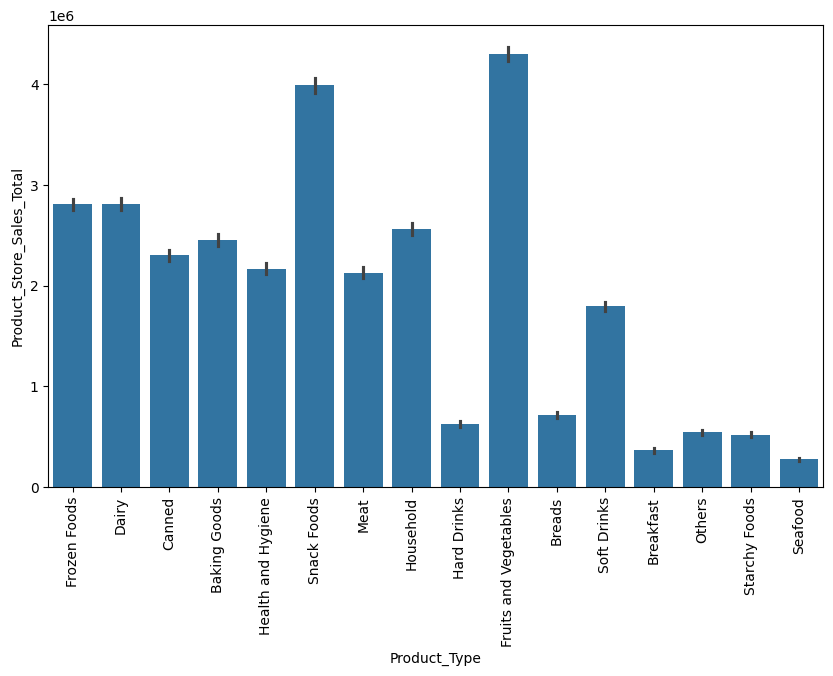

```python
plt.figure(figsize = (10,6))
sns.barplot(x='Product_Type', y='Product_Store_Sales_Total', data=skdf, estimator=sum)
plt.xticks(rotation=90)
plt.show()
```

- Above bar plot clearly shows significant difference in total sales accross product catergories.
- "Fruits and Vegetables", "Snack Foods" contribute to highest total sales and "Seafood" and "Breakfask" contribute to lowest sales.
- Based on our observation of no. products for each product type, total sales is partly influenced by number of products in each category.
- Average sale value for each product type fall in same range and similary Mean & Medians as wel with slightly variations.
- Hence we can say product type allone can not be strong predictor for total sales.
- **We need to perform one hot encoding to the Product Type Variable.**

```python
skdf.groupby(['Store_Id'])['Product_Store_Sales_Total'].agg([sum, min, max, np.mean, np.median, np.std])
```

| Store_Id | sum | min | max | mean | median | std |
| --- | --- | --- | --- | --- | --- | --- |
| OUT001 | 6223113.18 | 2300.56 | 4997.63 | 3923.778802 | 4139.645 | 904.629010 |
| OUT002 | 2030909.72 | 33.00 | 2299.63 | 1762.942465 | 1889.495 | 462.862431 |
| OUT003 | 6673457.57 | 3069.24 | 8000.00 | 4946.966323 | 4958.290 | 677.539953 |
| OUT004 | 15427583.43 | 1561.06 | 5462.86 | 3299.312111 | 3304.180 | 468.271692 |

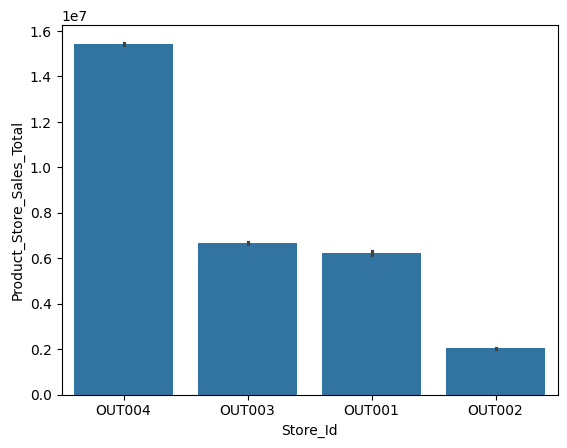

```python
sns.barplot(x='Store_Id', y='Product_Store_Sales_Total', data=skdf, estimator=sum)
plt.show()
```

- Above bar plot clearly shows there is significant difference in total stores generated by each store.
- OUT004 is having higher sales, where as OUT003 & OUT001 is having moderate sales, while OUT002 have low sales.
- By looking at average, mean, median and no.products, STD across stores, we can observer, Store ID plays a crucial role in determining product sales performance.
- **Since Store ID is categorical value, we would need to perform One Hot Encoding for Store_Id while model development.**

```python
skdf.groupby(['Store_Size'])['Product_Store_Sales_Total'].agg([sum, min, max, np.mean, np.median, np.std])
```

| Store_Size | sum | min | max | mean | median | std |
| --- | --- | --- | --- | --- | --- | --- |
| High | 6223113.18 | 2300.56 | 4997.63 | 3923.778802 | 4139.645 | 904.629010 |
| Medium | 22101041.00 | 1561.06 | 8000.00 | 3668.222573 | 3511.100 | 862.970819 |
| Small | 2030909.72 | 33.00 | 2299.63 | 1762.942465 | 1889.495 | 462.862431 |

```python
skdf.groupby(['Store_Size','Store_Id'])['Product_Store_Sales_Total'].agg([sum, min, max, np.mean, np.median, np.std])
```

| Store_Size | Store_Id | sum | min | max | mean | median | std |
| --- | --- | --- | --- | --- | --- | --- | --- |
| High | OUT001 | 6223113.18 | 2300.56 | 4997.63 | 3923.778802 | 4139.645 | 904.629010 |
| Medium | OUT003 | 6673457.57 | 3069.24 | 8000.00 | 4946.966323 | 4958.290 | 677.539953 |
|  | OUT004 | 15427583.43 | 1561.06 | 5462.86 | 3299.312111 | 3304.180 | 468.271692 |
| Small | OUT002 | 2030909.72 | 33.00 | 2299.63 | 1762.942465 | 1889.495 | 462.862431 |

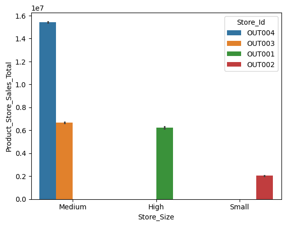

```python
sns.barplot(x='Store_Size', y='Product_Store_Sales_Total', data=skdf, estimator=sum, hue= 'Store_Id')
plt.show()
```

- Based on above bar graph, we can observe, Medium stores are generating higher sales.
- The Standard Deviation of sales is highes for 'High' sized stores, followed by Medium and then small, indicating more variability in sales per product in larger stores.
- Though store 4 & 3 both are Medium size stores, Store 3 outperforms store 4 with respect to Average and Store 4 outperforms store 3 in Total sales. Indicating, Store Size alone might not be key factor, however in combination of store id and store size influence the total sales.
- **Hence, we need to perform one hot encoding for store size as well.**

```python
skdf.groupby(['Store_Location_City_Type'])['Product_Store_Sales_Total'].agg([sum, min, max, np.mean, np.median, np.std])
```

| Store_Location_City_Type | sum | min | max | mean | median | std |
| --- | --- | --- | --- | --- | --- | --- |
| Tier 1 | 6673457.57 | 3069.24 | 8000.00 | 4946.966323 | 4958.290 | 677.539953 |
| Tier 2 | 21650696.61 | 1561.06 | 5462.86 | 3457.473109 | 3426.830 | 666.832121 |
| Tier 3 | 2030909.72 | 33.00 | 2299.63 | 1762.942465 | 1889.495 | 462.862431 |

```python
skdf.groupby(['Store_Location_City_Type','Store_Id'])['Product_Store_Sales_Total'].agg([sum, min, max, np.mean, np.median, np.std])
```

| Store_Location_City_Type | Store_Id | sum | min | max | mean | median | std |
| --- | --- | --- | --- | --- | --- | --- | --- |
| Tier 1 | OUT003 | 6673457.57 | 3069.24 | 8000.00 | 4946.966323 | 4958.290 | 677.539953 |
| Tier 2 | OUT001 | 6223113.18 | 2300.56 | 4997.63 | 3923.778802 | 4139.645 | 904.629010 |
|  | OUT004 | 15427583.43 | 1561.06 | 5462.86 | 3299.312111 | 3304.180 | 468.271692 |
| Tier 3 | OUT002 | 2030909.72 | 33.00 | 2299.63 | 1762.942465 | 1889.495 | 462.862431 |

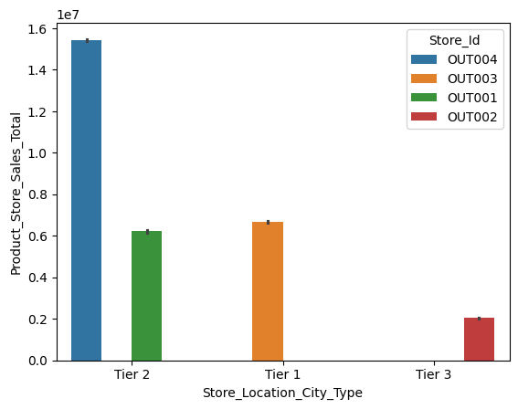

```python
sns.barplot(x='Store_Location_City_Type', y='Product_Store_Sales_Total', data=skdf, estimator=sum, hue= 'Store_Id')
plt.show()
```

- From above agregate statistics we can observer there is difference in Average, Median and STD values accross Tier1,Tier2 and Tier3.
- However from above bar graph and city ttype and store id combination, we can observer both Store4 and Store1 belongs to same tier, causing increase in total sales.
- Also, Store4 is having high sales compared to Store1 having contrasting performance, we can deduce city type is not the strong factor in predicting sales. And might only be helpful when compared with other features like store id.
- **We need to perform one hot encoding for city type.**

```python
skdf.groupby(['Store_Type'])['Product_Store_Sales_Total'].agg([sum, min, max, np.mean, np.median, np.std])
```

| Store_Type | sum | min | max | mean | median | std |
| --- | --- | --- | --- | --- | --- | --- |
| Departmental Store | 6673457.57 | 3069.24 | 8000.00 | 4946.966323 | 4958.290 | 677.539953 |
| Food Mart | 2030909.72 | 33.00 | 2299.63 | 1762.942465 | 1889.495 | 462.862431 |
| Supermarket Type1 | 6223113.18 | 2300.56 | 4997.63 | 3923.778802 | 4139.645 | 904.629010 |
| Supermarket Type2 | 15427583.43 | 1561.06 | 5462.86 | 3299.312111 | 3304.180 | 468.271692 |

```python
skdf.groupby(['Store_Type','Store_Id'])['Product_Store_Sales_Total'].agg([sum, min, max, np.mean, np.median, np.std])
```

| Store_Type | Store_Id | sum | min | max | mean | median | std |
| --- | --- | --- | --- | --- | --- | --- | --- |
| Departmental Store | OUT003 | 6673457.57 | 3069.24 | 8000.00 | 4946.966323 | 4958.290 | 677.539953 |
| Food Mart | OUT002 | 2030909.72 | 33.00 | 2299.63 | 1762.942465 | 1889.495 | 462.862431 |
| Supermarket Type1 | OUT001 | 6223113.18 | 2300.56 | 4997.63 | 3923.778802 | 4139.645 | 904.629010 |
| Supermarket Type2 | OUT004 | 15427583.43 | 1561.06 | 5462.86 | 3299.312111 | 3304.180 | 468.271692 |

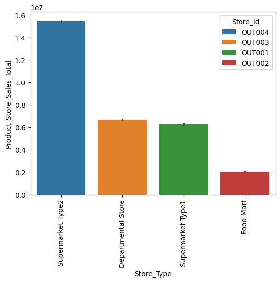

```python
sns.barplot(x='Store_Type', y='Product_Store_Sales_Total', data=skdf, estimator=sum, hue= 'Store_Id')
plt.xticks(rotation=90)
plt.show()
```

- Barplot shows the total sales by store type and "Supermarket Type2" has higher sales followed by "Departmental Store", "Supermarket type1" with "Food Mart" having least sales.
- Aggregate statistics Average,Median and STD deviate accross store types. Even though Supermarket Type2 having higher sales, it has lower average and median sales.
- Store Type is significant factor influencing total sales.
- **We can observer, Store ID and Store Type has one to one relationship in the dataset.**
- **'Store Id' identifies each store physically and 'Store Type' identifies each store based on store factors**
- **Hence we can either keep 'Store Id' or 'Store Type' in dataset rather than keeping both.**
- **As Store Id is physical representation or name field, we can consider to drop 'Store Id' and keep 'Store Type' for model development.**
- **Create one hot encoding to Store Type**

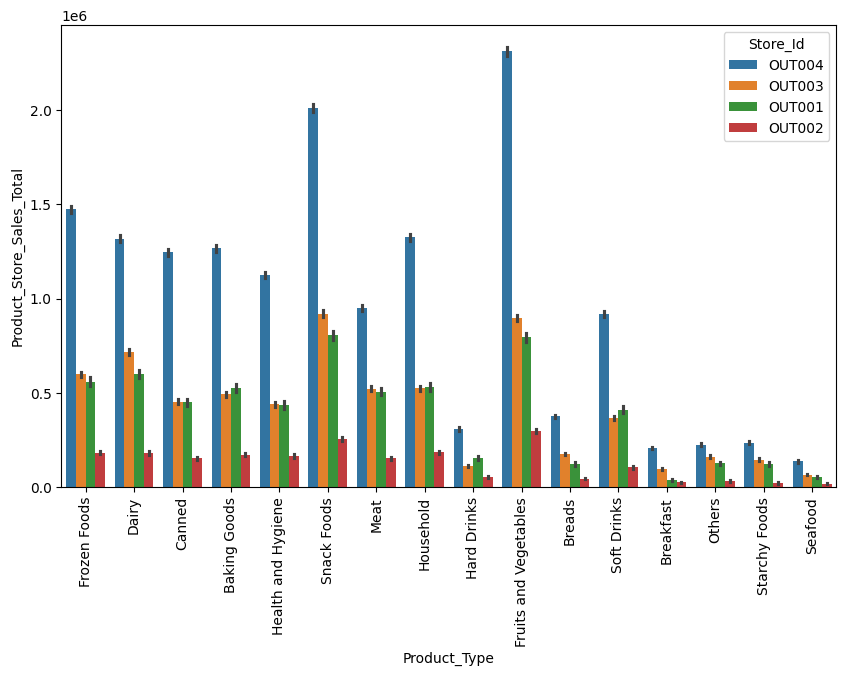

```python
plt.figure(figsize = (10,6))
sns.barplot(x='Product_Type', y='Product_Store_Sales_Total', data=skdf, hue='Store_Id',estimator=sum)
plt.xticks(rotation=90)
plt.show()
```

- Each store consists of all the 16 product types.
- Performance of each store is similar across the product types.

```python
skdf.groupby(['Store_Type',skdf.Product_Id.str[:2],'Product_Type'])['Product_Store_Sales_Total'].agg([sum, min, max, np.mean, np.median, np.std])
```

| Store_Type | Product_Id | Product_Type | sum | min | max | mean | median | std |
| --- | --- | --- | --- | --- | --- | --- | --- | --- |
| Departmental Store | DR | Hard Drinks | 110760.30 | 4205.63 | 6347.57 | 4815.665217 | 4475.200 | 629.474435 |
|  |  | Soft Drinks | 365046.30 | 3999.51 | 6697.87 | 4933.058108 | 4747.810 | 681.142774 |
|  | FD | Baking Goods | 491908.20 | 4216.97 | 6763.94 | 4968.769697 | 5009.100 | 668.174194 |
|  |  | Breads | 175391.93 | 4221.01 | 6660.96 | 5158.586176 | 5128.995 | 619.215635 |
|  |  | Breakfast | 95634.08 | 4259.99 | 6796.94 | 5033.372632 | 5031.710 | 686.932668 |
|  |  | Canned | 452445.17 | 4200.52 | 6862.43 | 5027.168556 | 5096.735 | 658.425919 |
|  |  | Dairy | 715814.94 | 3724.32 | 6835.81 | 4936.654759 | 4797.650 | 723.702623 |
|  |  | Frozen Foods | 597608.42 | 3069.24 | 6747.70 | 4898.429672 | 4974.955 | 624.287177 |
|  |  | Fruits and Vegetables | 897437.46 | 3666.96 | 6744.58 | 4930.975055 | 4936.325 | 684.466778 |
|  |  | Meat | 520939.68 | 4204.20 | 6711.59 | 4914.525283 | 4877.630 | 617.616283 |
|  |  | Seafood | 65337.48 | 4211.02 | 5897.01 | 5025.960000 | 5087.860 | 558.844340 |
|  |  | Snack Foods | 918510.44 | 4201.05 | 6977.43 | 4938.228172 | 4961.450 | 675.758988 |
|  |  | Starchy Foods | 143538.60 | 4259.43 | 6736.81 | 5126.378571 | 5085.300 | 694.206204 |
|  | NC | Health and Hygiene | 439139.18 | 3163.73 | 6643.63 | 4934.148090 | 4490.960 | 744.093348 |
|  |  | Household | 523981.64 | 4202.58 | 8000.00 | 4897.024673 | 4494.620 | 705.681952 |
|  |  | Others | 159963.75 | 4214.83 | 6740.07 | 4998.867188 | 4797.395 | 762.860394 |
| Food Mart | DR | Hard Drinks | 54281.85 | 705.86 | 2299.63 | 1809.395000 | 1930.620 | 450.345652 |
|  |  | Soft Drinks | 103808.35 | 501.72 | 2296.00 | 1674.328226 | 1817.930 | 517.492660 |
|  | FD | Baking Goods | 169860.50 | 203.55 | 2296.99 | 1769.380208 | 1886.600 | 434.950975 |
|  |  | Breads | 43419.47 | 830.76 | 2297.15 | 1887.803043 | 1955.400 | 389.592534 |
|  |  | Breakfast | 23396.10 | 657.14 | 2243.79 | 1559.740000 | 1615.930 | 547.769644 |
|  |  | Canned | 151467.66 | 180.86 | 2285.44 | 1721.223409 | 1823.560 | 457.609184 |
|  |  | Dairy | 178888.18 | 183.02 | 2269.67 | 1720.078654 | 1848.975 | 478.887388 |
|  |  | Frozen Foods | 180295.95 | 350.00 | 2296.65 | 1785.108416 | 1915.790 | 461.496154 |
|  |  | Fruits and Vegetables | 298503.56 | 366.37 | 2295.41 | 1776.806905 | 1876.630 | 443.212089 |
|  |  | Meat | 151800.01 | 166.92 | 2261.67 | 1744.827701 | 1879.760 | 450.102714 |
|  |  | Seafood | 17663.35 | 829.10 | 2295.72 | 1766.335000 | 1834.605 | 426.288552 |
|  |  | Snack Foods | 255317.57 | 33.00 | 2281.16 | 1748.750479 | 1840.715 | 436.243332 |
|  |  | Starchy Foods | 20044.98 | 715.02 | 2221.45 | 1670.415000 | 1807.545 | 565.935046 |
|  | NC | Health and Hygiene | 164660.81 | 253.53 | 2299.50 | 1809.459451 | 1957.850 | 508.502909 |
|  |  | Household | 184665.65 | 512.42 | 2292.63 | 1846.656500 | 2005.720 | 443.848367 |
|  |  | Others | 32835.73 | 369.31 | 2298.72 | 1728.196316 | 1949.810 | 620.387103 |
| Supermarket Type1 | DR | Hard Drinks | 152920.74 | 2300.68 | 4976.47 | 4024.230000 | 4356.350 | 901.045928 |
|  |  | Soft Drinks | 410548.69 | 2310.65 | 4934.29 | 3873.100849 | 4097.450 | 878.210513 |
|  | FD | Baking Goods | 525131.04 | 2306.99 | 4944.48 | 3861.257647 | 4110.935 | 909.174139 |
|  |  | Breads | 121274.09 | 2301.45 | 4997.63 | 4042.469667 | 4544.105 | 987.742681 |
|  |  | Breakfast | 38161.10 | 2339.85 | 4866.21 | 3816.110000 | 4117.520 | 997.159841 |
|  |  | Canned | 449016.38 | 2309.79 | 4986.71 | 3773.246891 | 4086.690 | 953.999677 |
|  |  | Dairy | 598767.62 | 2303.60 | 4986.87 | 3991.784133 | 4131.925 | 877.583506 |
|  |  | Frozen Foods | 558556.81 | 2311.60 | 4965.80 | 3933.498662 | 4177.145 | 950.110795 |
|  |  | Fruits and Vegetables | 792992.59 | 2301.68 | 4984.16 | 3984.887387 | 4162.050 | 879.274460 |
|  |  | Meat | 505867.28 | 2301.85 | 4970.29 | 3891.286769 | 4097.495 | 873.279876 |
|  |  | Seafood | 52936.84 | 2357.24 | 4706.76 | 4072.064615 | 4183.750 | 792.293395 |
|  |  | Snack Foods | 806142.24 | 2300.58 | 4995.61 | 3990.803168 | 4163.240 | 898.060966 |
|  |  | Starchy Foods | 120443.98 | 2302.86 | 4851.45 | 3763.874375 | 4083.175 | 985.854879 |
|  | NC | Health and Hygiene | 435005.31 | 2311.05 | 4945.96 | 3815.836053 | 4107.725 | 929.045521 |
|  |  | Household | 531371.38 | 2300.56 | 4939.33 | 3965.458060 | 4157.585 | 882.961173 |
|  |  | Others | 123977.09 | 2314.66 | 4870.75 | 3999.260968 | 4510.260 | 923.733168 |
| Supermarket Type2 | DR | Hard Drinks | 307851.73 | 2126.69 | 5258.01 | 3240.544526 | 3205.040 | 514.842795 |
|  |  | Soft Drinks | 917641.38 | 2372.03 | 5204.13 | 3312.784765 | 3319.480 | 430.635657 |
|  | FD | Baking Goods | 1266086.26 | 1737.15 | 5462.86 | 3288.535740 | 3265.940 | 464.351813 |
|  |  | Breads | 374856.75 | 2502.63 | 3993.19 | 3317.316372 | 3358.670 | 416.697588 |
|  |  | Breakfast | 204939.13 | 2514.34 | 3929.70 | 3305.469839 | 3371.850 | 437.076239 |
|  |  | Canned | 1247153.50 | 2046.37 | 5209.49 | 3281.982895 | 3283.365 | 479.418470 |
|  |  | Dairy | 1318447.30 | 1852.12 | 4912.92 | 3321.025945 | 3361.360 | 433.985536 |
|  |  | Frozen Foods | 1473519.65 | 1740.27 | 5007.32 | 3303.855717 | 3283.960 | 468.655214 |
|  |  | Fruits and Vegetables | 2311899.66 | 1578.54 | 5339.90 | 3302.713800 | 3316.565 | 465.351749 |
|  |  | Meat | 950604.97 | 2274.43 | 5117.70 | 3222.389729 | 3193.590 | 455.771809 |
|  |  | Seafood | 136466.37 | 2142.41 | 5341.06 | 3411.659250 | 3464.230 | 640.583819 |
|  |  | Snack Foods | 2009026.70 | 1561.06 | 5064.03 | 3266.710081 | 3271.170 | 458.778548 |
|  |  | Starchy Foods | 234746.89 | 1640.82 | 5256.36 | 3402.128841 | 3452.360 | 487.475157 |
|  | NC | Health and Hygiene | 1124901.91 | 2152.78 | 5419.82 | 3367.969790 | 3390.195 | 518.433855 |
|  |  | Household | 1324721.50 | 2028.38 | 5304.55 | 3320.104010 | 3306.310 | 487.610050 |
|  |  | Others | 224719.73 | 2525.08 | 3985.57 | 3256.807681 | 3301.780 | 410.153936 |

- Upon revieweing first two charecters of Product ID, we can observe these two letters used to group the product types. Like
  - DR: Drinks
  - FD: Food
  - NC: Non-Consumable
- Since we have product_type having much granular, having additional product. group might not be much beneficial and including it might cause multilinearity.
- Hence not adding the feature.

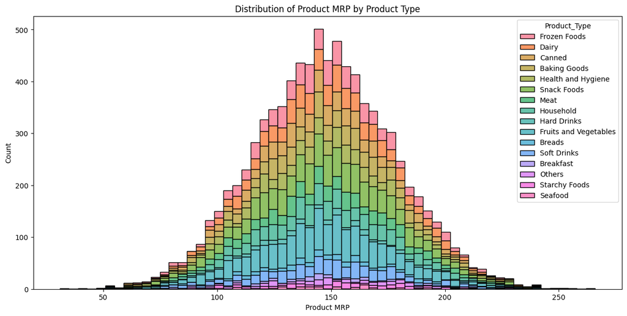

```python
plt.figure(figsize=(15, 7))
sns.histplot(data=skdf, x='Product_MRP', hue='Product_Type', multiple='stack')
plt.title('Distribution of Product MRP by Product Type')
plt.xlabel('Product MRP')
plt.ylabel('Count')
plt.show()
```

```python
skdf.groupby(['Store_Id','Store_Establishment_Year'])['Product_Id'].count()
```

| Store_Id | Store_Establishment_Year | Product_Id |
| --- | --- | --- |
| OUT001 | 1987 | 1586 |
| OUT002 | 1998 | 1152 |
| OUT003 | 1999 | 1349 |
| OUT004 | 2009 | 4676 |

**dtype:** int64